# Life History Attributes Influencing Metabolic Variation in an Estuarine Fish

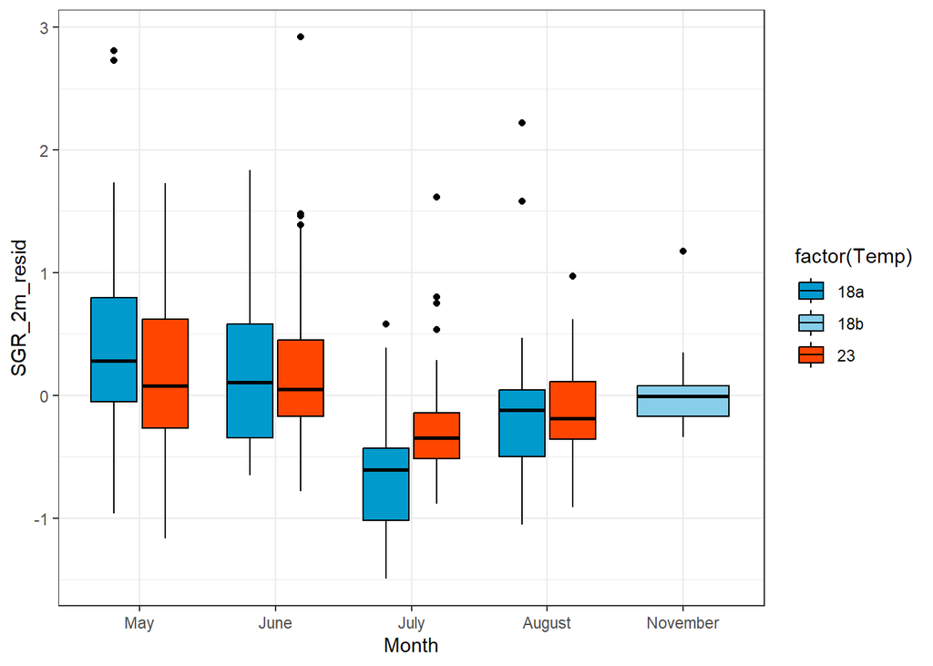

Now we move on to look at the relationship between SGR and mass-standardized SMR.

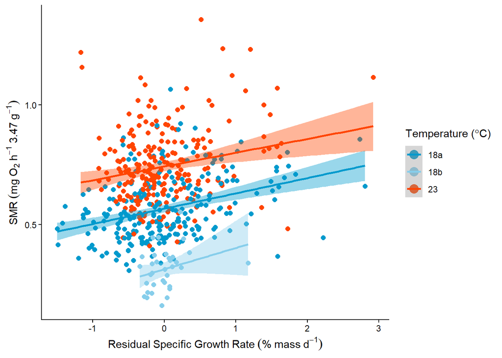

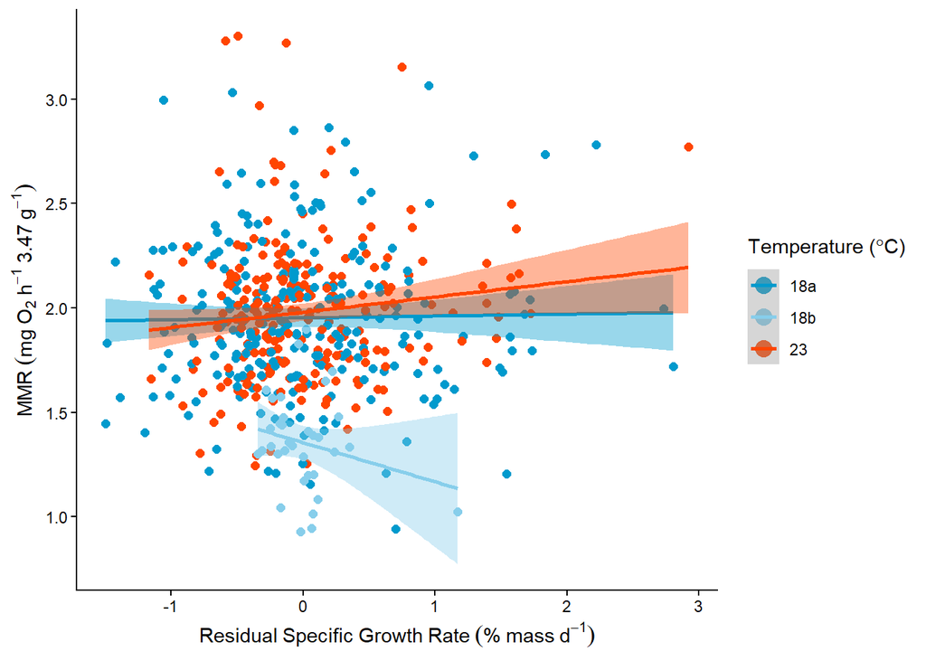

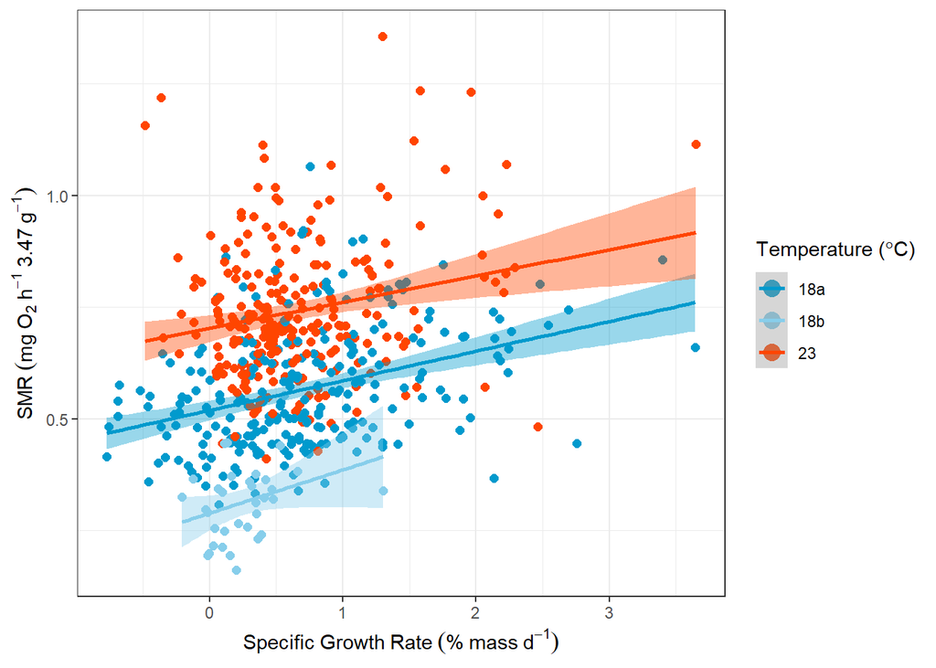

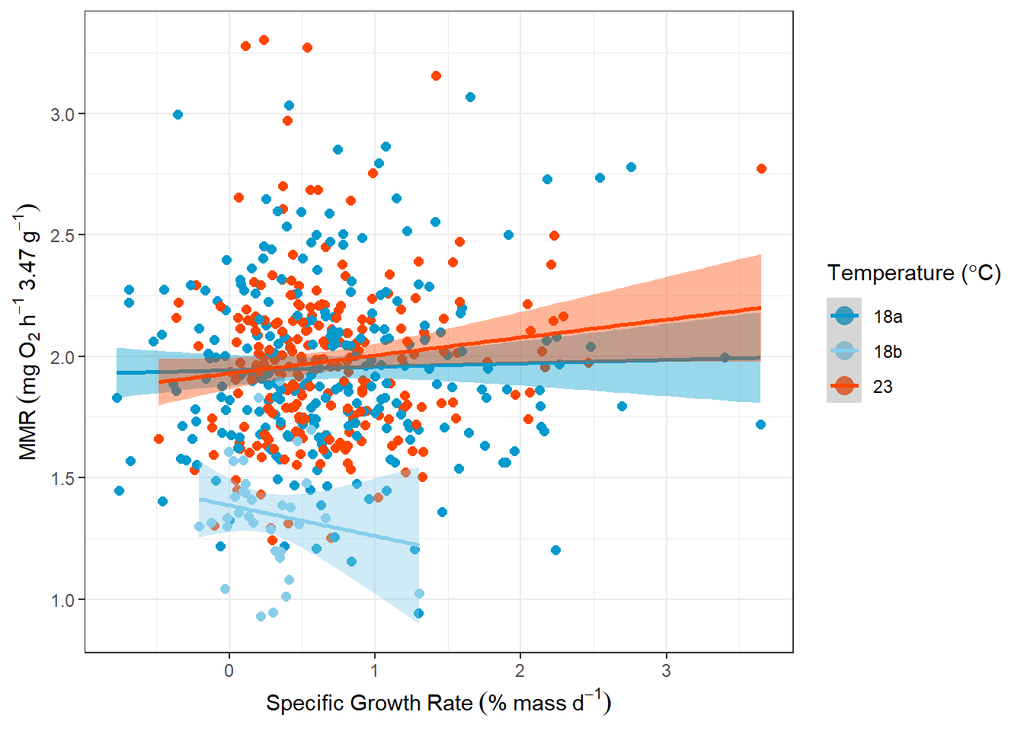

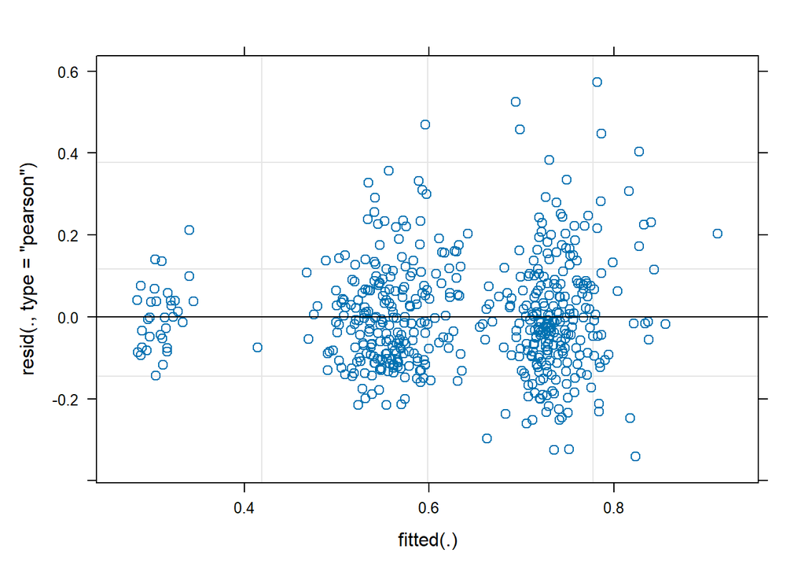

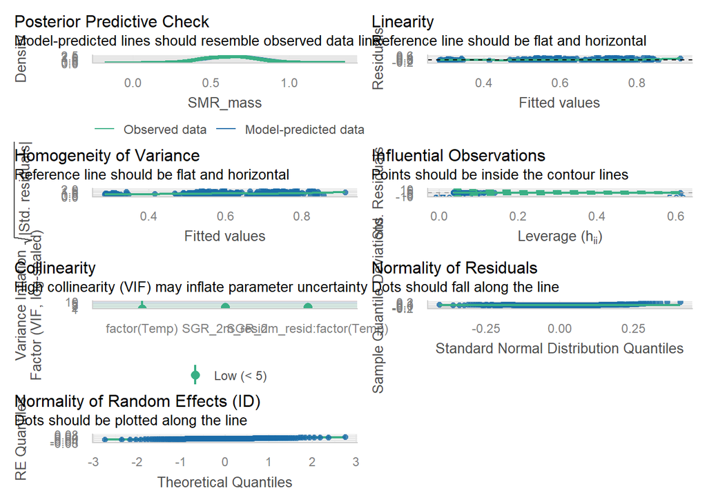

```
## Linear mixed model fit by REML. t-tests use Satterthwaite's method [
## lmerModLmerTest]
## Formula: SMR_mass ~ SGR_2m_resid * factor(Temp) + (1 | ID)
##    Data: data_sgr
##
## REML criterion at convergence: -561.6
##
## Scaled residuals:
##     Min      1Q  Median      3Q     Max
## -2.5341 -0.6656 -0.1004  0.5076  4.2571
##
## Random effects:
##  Groups   Name        Variance Std.Dev.
##  ID       (Intercept) 0.000679 0.02606
##  Residual             0.018160 0.13476
## Number of obs: 522, groups:  ID, 166
##
## Fixed effects:
##                                Estimate Std. Error         df t value Pr(>|t|)
## (Intercept)                    0.566214   0.009191 143.042177  61.607  < 2e-16
## SGR_2m_resid                   0.064463   0.012236 513.282167   5.268 2.03e-07
## factor(Temp)18b               -0.253157   0.025270 481.084370 -10.018  < 2e-16
## factor(Temp)23                 0.175875   0.013052 134.381633  13.475  < 2e-16
## SGR_2m_resid:factor(Temp)18b   0.024302   0.088947 513.864317   0.273    0.785
## SGR_2m_resid:factor(Temp)23   -0.007195   0.019902 486.211853  -0.362    0.718
##
## (Intercept)                  ***
## SGR_2m_resid                 ***
## factor(Temp)18b              ***
## factor(Temp)23               ***
## SGR_2m_resid:factor(Temp)18b
## SGR_2m_resid:factor(Temp)23
## ---
## Signif. codes:  0 '***' 0.001 '**' 0.01 '*' 0.05 '.' 0.1 ' ' 1
##
## Correlation of Fixed Effects:
##             (Intr) SGR_2m_ f(T)18 f(T)23 SGR_2_:(T)1
## SGR_2m_resd -0.003
## fctr(Tmp)18 -0.364  0.001
## fctr(Tmp)23 -0.704  0.002   0.256
## SGR_2_:(T)1  0.000 -0.138   0.000  0.000
## SGR_2_:(T)2  0.002 -0.615  -0.001 -0.001  0.085
```

```
## Linear mixed model fit by REML. t-tests use Satterthwaite's method [
## lmerModLmerTest]
## Formula: SMR_mass ~ SGR_2m_resid + (1 | ID)
##    Data: data_sgr[which(data_sgr$Temp == "18a" | data_sgr$Temp == "18b"),
##     ]
##
## REML criterion at convergence: -269.2
##
## Scaled residuals:
##     Min      1Q  Median      3Q     Max
## -2.4177 -0.6115 -0.0447  0.6001  3.3869
##
## Random effects:
##  Groups   Name        Variance Std.Dev.
##  ID       (Intercept) 0.001465 0.03828
##  Residual             0.019991 0.14139
## Number of obs: 279, groups:  ID, 105
##
## Fixed effects:
##               Estimate Std. Error        df t value Pr(>|t|)
## (Intercept)  5.306e-01  9.443e-03 2.916e+01  56.193  < 2e-16 ***
## SGR_2m_resid 6.553e-02  1.292e-02 2.768e+02   5.072 7.23e-07 ***
## ---
## Signif. codes:  0 '***' 0.001 '**' 0.01 '*' 0.05 '.' 0.1 ' ' 1
##
## Correlation of Fixed Effects:
##             (Intr)
## SGR_2m_resd -0.005
```

```
## $model
## [1] 0.1440702
##
## $fixed
## [1] 0.0820092
##
## $random
## [1] 0.06206104
```

```
## Linear mixed model fit by REML. t-tests use Satterthwaite's method [
## lmerModLmerTest]
## Formula: SMR_mass ~ SGR_2m_resid + (1 | ID)
##    Data: data_sgr[which(data_sgr$Temp == "18a"), ]
##
## REML criterion at convergence: -311.6
##
## Scaled residuals:
##     Min      1Q  Median      3Q     Max
## -2.4133 -0.7414 -0.1105  0.5810  3.9592
##
## Random effects:
##  Groups   Name        Variance Std.Dev.
##  ID       (Intercept) 0.00000  0.0000
##  Residual             0.01557  0.1248
## Number of obs: 245, groups:  ID, 71
##
## Fixed effects:
##               Estimate Std. Error        df t value Pr(>|t|)
## (Intercept)  5.660e-01  7.971e-03 2.430e+02  71.007  < 2e-16 ***
## SGR_2m_resid 6.399e-02  1.110e-02 2.430e+02   5.765 2.46e-08 ***
## ---
## Signif. codes:  0 '***' 0.001 '**' 0.01 '*' 0.05 '.' 0.1 ' ' 1
##
## Correlation of Fixed Effects:
##             (Intr)
## SGR_2m_resd 0.000
## optimizer (nloptwrap) convergence code: 0 (OK)
## boundary (singular) fit: see help('isSingular')
```

```
## $model
## [1] 0.1203208
##
## $fixed
## [1] 0.1203208
##
## $random
## [1] 0
```

```
##
## Call:
## lm(formula = log10(SMR_mass) ~ SGR_2m_resid, data = data_sgr[which(data_sgr$Temp ==
##     "18b"), ])
##
## Residuals:
##      Min       1Q   Median       3Q      Max
## -0.26703 -0.09179  0.01466  0.06963  0.23395
##
## Coefficients:
##              Estimate Std. Error t value Pr(>|t|)
## (Intercept)  -0.52047    0.02026 -25.692   <2e-16 ***
## SGR_2m_resid  0.12824    0.07582   1.691      0.1
## ---
## Signif. codes:  0 '***' 0.001 '**' 0.01 '*' 0.05 '.' 0.1 ' ' 1
##
## Residual standard error: 0.1181 on 32 degrees of freedom
## Multiple R-squared:  0.08206,    Adjusted R-squared:  0.05337
## F-statistic: 2.861 on 1 and 32 DF,  p-value: 0.1005
```

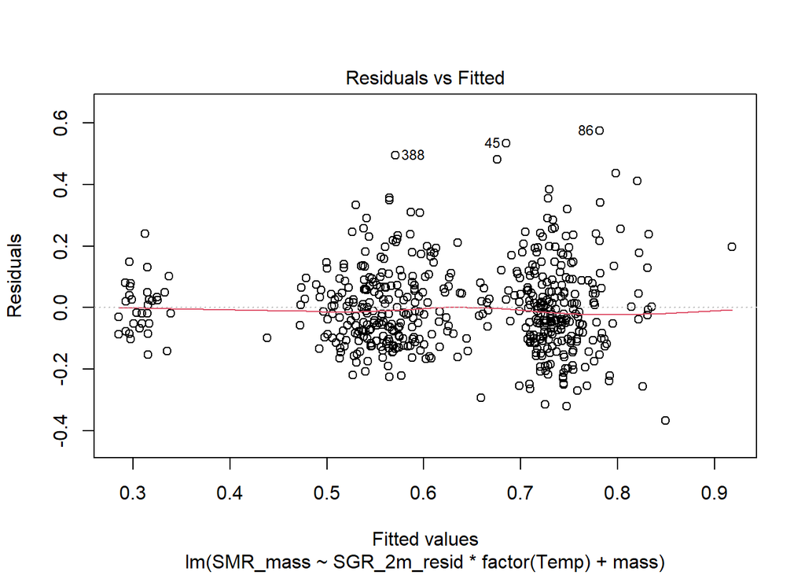

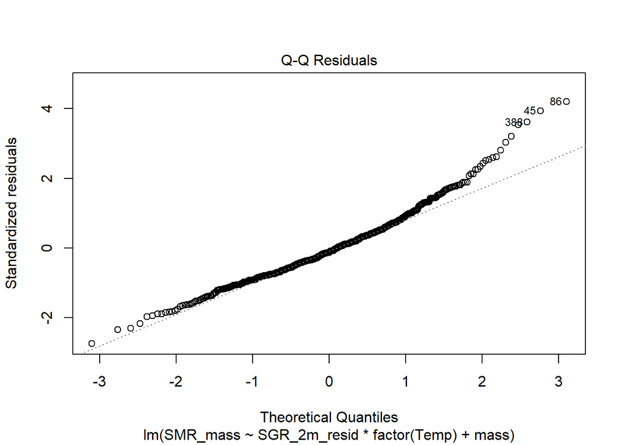

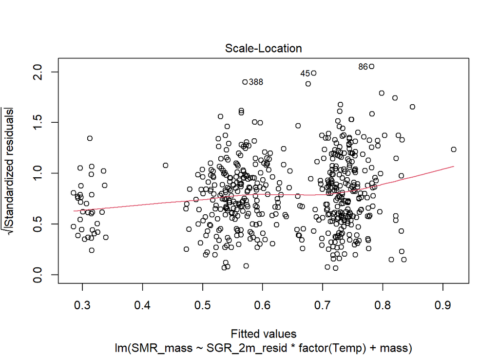

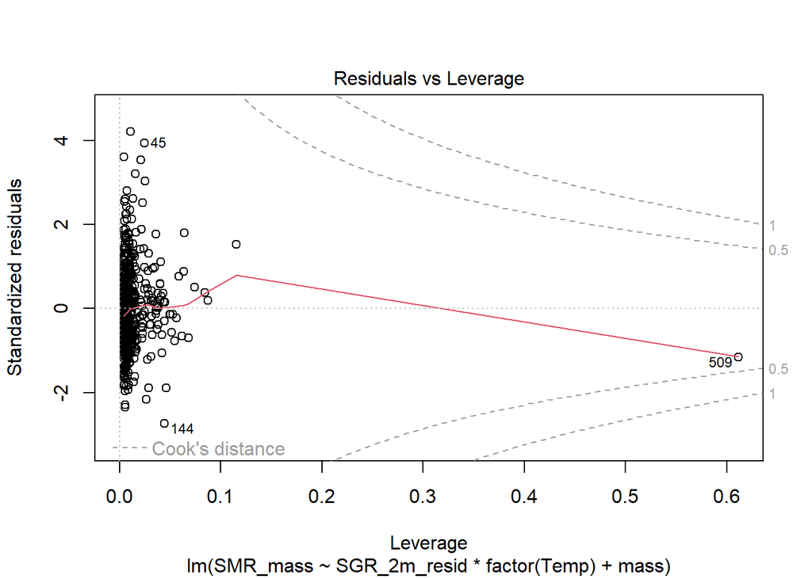

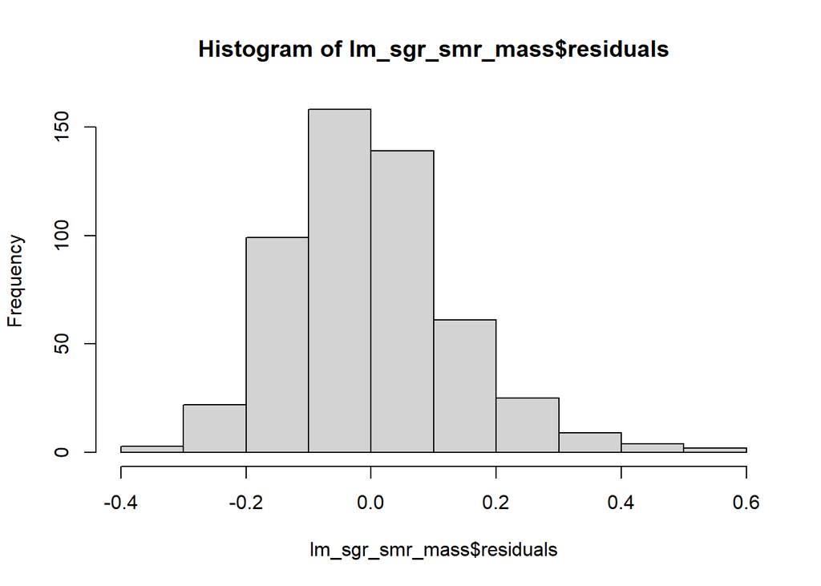

```
##
## Call:
## lm(formula = SMR_mass ~ SGR_2m_resid * factor(Temp) + mass, data = data_sgr)
##
## Residuals:
##      Min       1Q   Median       3Q      Max
## -0.36758 -0.09503 -0.01684  0.07166  0.57419
##
## Coefficients:
##                               Estimate Std. Error t value Pr(>|t|)
## (Intercept)                   0.582626   0.016005  36.402  < 2e-16 ***
## SGR_2m_resid                  0.064084   0.012204   5.251 2.21e-07 ***
## factor(Temp)18b              -0.242298   0.026512  -9.139  < 2e-16 ***
## factor(Temp)23                0.172923   0.012684  13.633  < 2e-16 ***
## mass                         -0.005144   0.004136  -1.244    0.214
## SGR_2m_resid:factor(Temp)18b  0.027787   0.088915   0.313    0.755
## SGR_2m_resid:factor(Temp)23  -0.006197   0.019743  -0.314    0.754
## ---
## Signif. codes:  0 '***' 0.001 '**' 0.01 '*' 0.05 '.' 0.1 ' ' 1
##
## Residual standard error: 0.1372 on 515 degrees of freedom
## Multiple R-squared:  0.4613, Adjusted R-squared:  0.455
## F-statistic:  73.5 on 6 and 515 DF,  p-value: < 2.2e-16
```

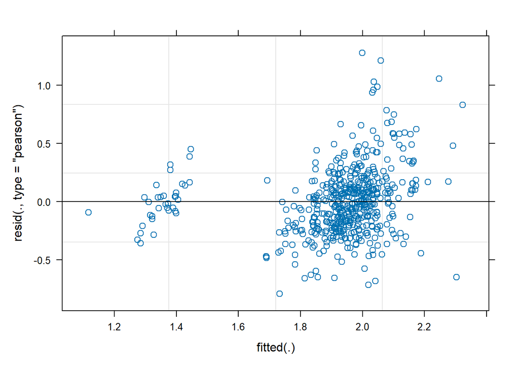

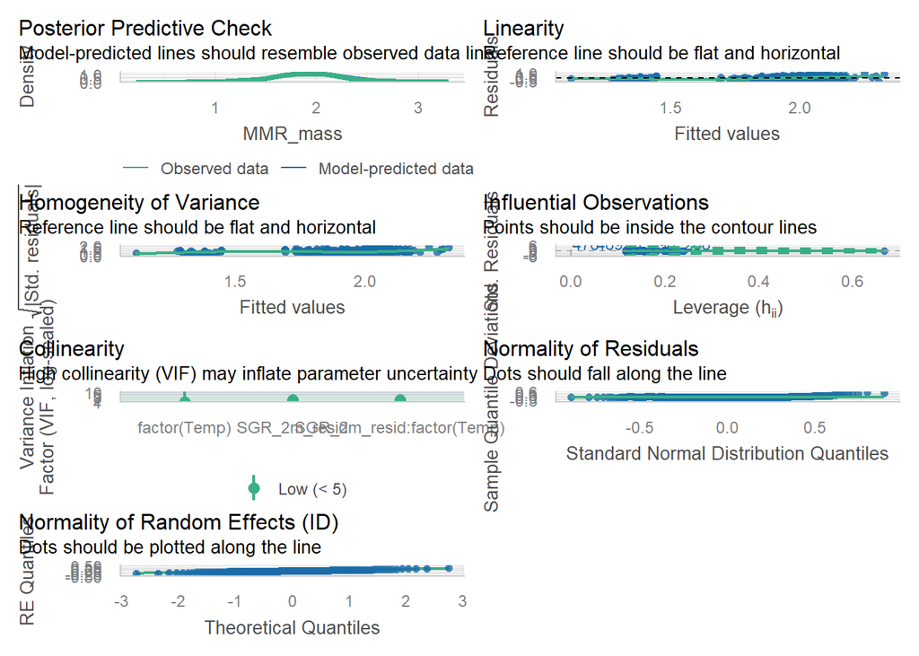

```
## Linear mixed model fit by REML. t-tests use Satterthwaite's method [
## lmerModLmerTest]
## Formula: MMR_mass ~ SGR_2m_resid * factor(Temp) + (1 | ID)
##    Data: data_sgr
##
## REML criterion at convergence: 355.6
##
## Scaled residuals:
##     Min      1Q  Median      3Q     Max
## -2.5633 -0.6470 -0.0502  0.4687  4.1444
##
## Random effects:
##  Groups   Name        Variance Std.Dev.
##  ID       (Intercept) 0.02002  0.1415
##  Residual             0.09528  0.3087
## Number of obs: 522, groups:  ID, 166
##
## Fixed effects:
##                               Estimate Std. Error        df t value Pr(>|t|)
## (Intercept)                    1.95260    0.02626 137.90219  74.368   <2e-16
## SGR_2m_resid                   0.00348    0.02970 509.36165   0.117    0.907
## factor(Temp)18b               -0.59716    0.06388 405.18675  -9.348   <2e-16
## factor(Temp)23                 0.02718    0.03755 129.49611   0.724    0.470
## SGR_2m_resid:factor(Temp)18b  -0.19102    0.21997 477.17180  -0.868    0.386
## SGR_2m_resid:factor(Temp)23    0.05815    0.04902 515.93933   1.186    0.236
##
## (Intercept)                  ***
## SGR_2m_resid
## factor(Temp)18b              ***
## factor(Temp)23
## SGR_2m_resid:factor(Temp)18b
## SGR_2m_resid:factor(Temp)23
## ---
## Signif. codes:  0 '***' 0.001 '**' 0.01 '*' 0.05 '.' 0.1 ' ' 1
##
## Correlation of Fixed Effects:
##             (Intr) SGR_2m_ f(T)18 f(T)23 SGR_2_:(T)1
## SGR_2m_resd -0.011
## fctr(Tmp)18 -0.411  0.005
## fctr(Tmp)23 -0.699  0.008   0.287
## SGR_2_:(T)1  0.002 -0.135  -0.001 -0.001
## SGR_2_:(T)2  0.007 -0.606  -0.003 -0.005  0.082
```

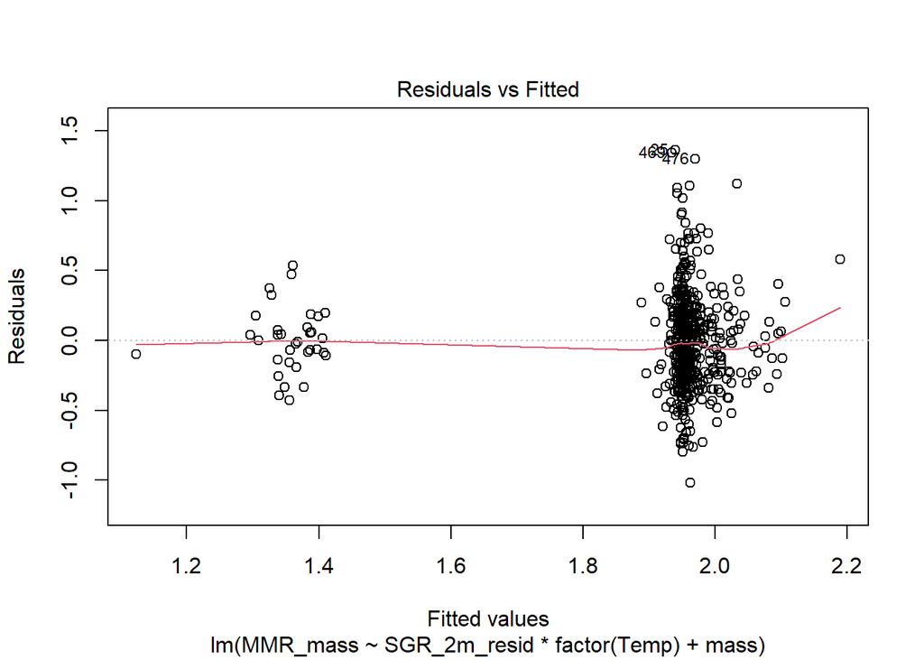

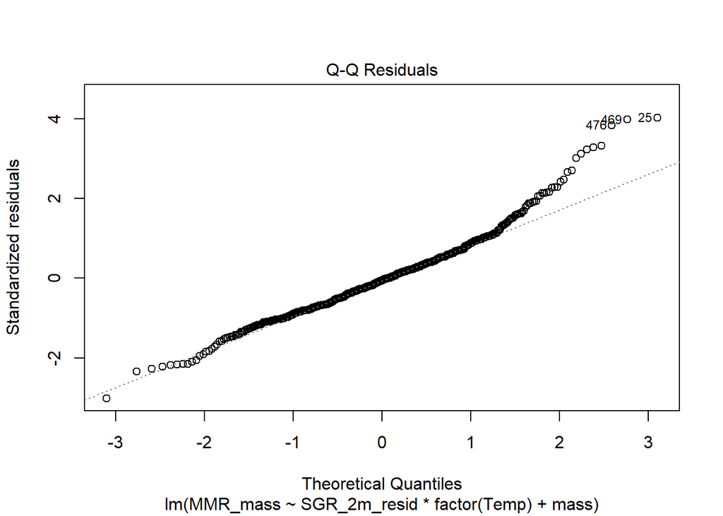

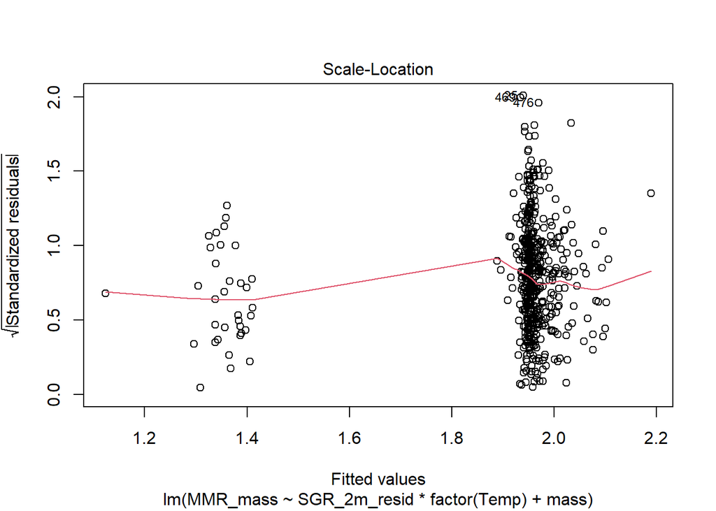

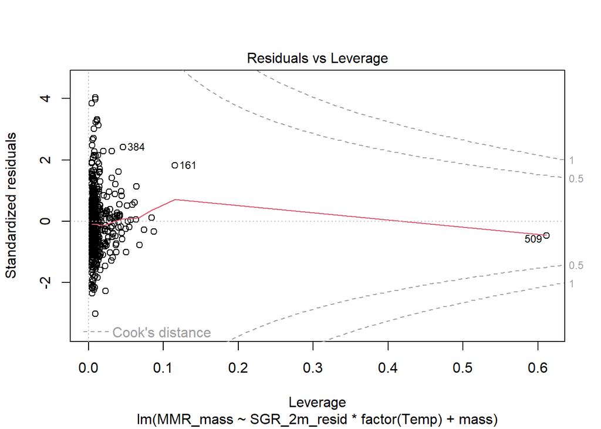

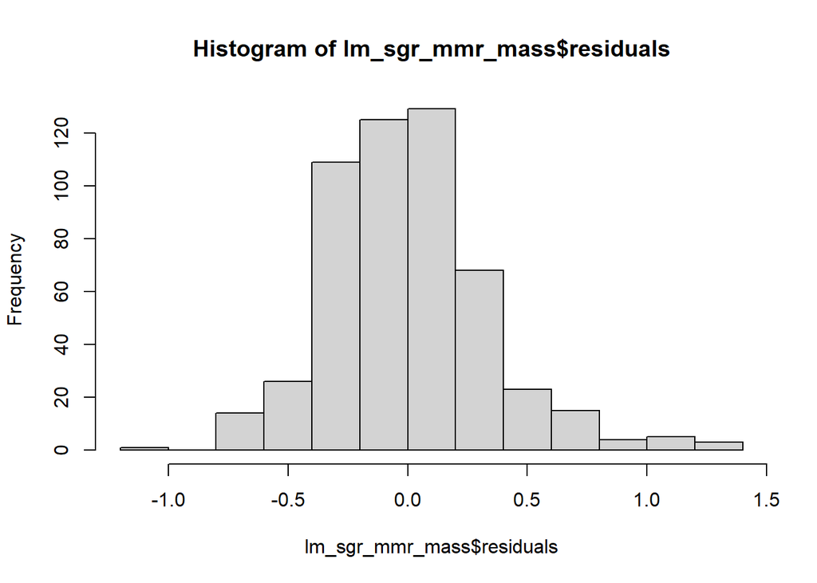

```
##
## Call:
## lm(formula = MMR_mass ~ SGR_2m_resid * factor(Temp) + mass, data = data_sgr)
##
## Residuals:
##      Min       1Q   Median       3Q      Max
## -1.02070 -0.22865 -0.01981  0.17685  1.36170
##
## Coefficients:
##                               Estimate Std. Error t value Pr(>|t|)
## (Intercept)                   1.943794   0.039604  49.080   <2e-16 ***
## SGR_2m_resid                  0.008967   0.030197   0.297    0.767
## factor(Temp)18b              -0.603814   0.065602  -9.204   <2e-16 ***
## factor(Temp)23                0.028306   0.031386   0.902    0.368
## mass                          0.002915   0.010233   0.285    0.776
## SGR_2m_resid:factor(Temp)18b -0.198267   0.220013  -0.901    0.368
## SGR_2m_resid:factor(Temp)23   0.064163   0.048852   1.313    0.190
## ---
## Signif. codes:  0 '***' 0.001 '**' 0.01 '*' 0.05 '.' 0.1 ' ' 1
##
## Residual standard error: 0.3394 on 515 degrees of freedom
## Multiple R-squared:  0.1738, Adjusted R-squared:  0.1641
## F-statistic: 18.05 on 6 and 515 DF,  p-value: < 2.2e-16
```

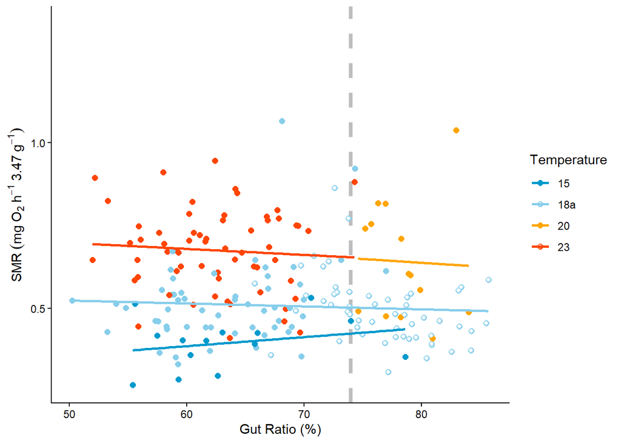

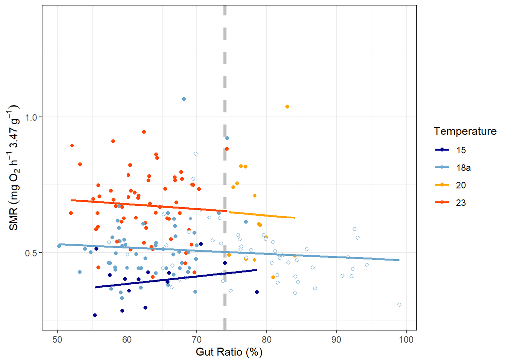

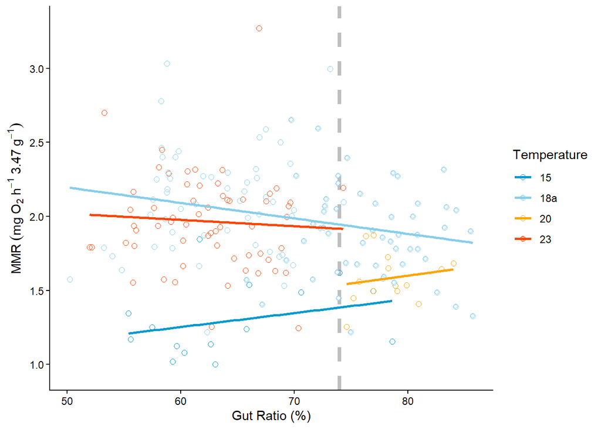

```r
# plot gut ratio vs. mass-standardized MMR, indicate extrapolated values:
fig6 <- ggplot() +
  geom_vline(xintercept = 74, color = "grey", linetype = "dashed", linewidth = 1.5) +
  geom_point(data = datamat, aes(x = Ratio, y = MMR_mass, color = factor(Temp)), shape = 21, size = 2) +
  geom_point(data = datamat[which(data$Month == "July"),], aes(x = Ratio, y = MMR_mass, color = factor(Temp)), shape = 21, fill = "white")+
  geom_smooth(data = datamat, aes(x = Ratio, y = MMR_mass, color = factor(Temp)), method = "lm", se = F) +
  scale_color_manual(values =c("deepskyblue3", "skyblue", "orange", "orangered"),
    guide = guide_legend()) +
  labs(x = "Gut Ratio (%)", y = expression(MMR~(mg~O[2]~h^-1~3.47~g^-1)), color = "Temperature") +
  theme_classic()

fig6
```

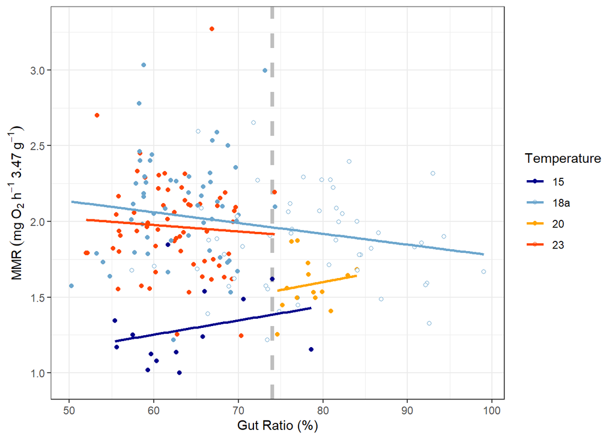

```r
# gut ratio vs. mass-standardized MMR but using linearly extrapolated gut ratio values:
ggplot() +
  geom_vline(xintercept = 74, color = "grey", linetype = "dashed", size = 1.5) +
  geom_point(data = datamat, aes(x = Ratio_linear, y = MMR_mass, color = factor(Temp))) +
  geom_point(data = datamat[which(data$Month == "July"),], aes(x = Ratio_linear, y = MMR_mass, color = factor(Temp)), shape = 21, fill = "white") +
  geom_smooth(data = datamat, aes(x = Ratio_linear, y = MMR_mass, color = factor(Temp)), method = "lm", se = F) +
  theme_bw() +
  scale_color_manual(values =c("darkblue", "skyblue3", "orange", "orangered")) +
  labs(x = "Gut Ratio (%)", y = expression(MMR~(mg~O[2]~h^-1~3.47~g^-1)), color = "Temperature")
```

Gut ratio really does not seem to have any correlation with mass-standardized SMR (any correlation seen between gut ratio and SMR could be explained by mass). Note that this figure uses the previously extrapolated values (above). For MMR, the case is a bit more complicated.

One way to explore this from a different perspective is to treat maturation as a binary state rather than a continuous variable. I will add a new column to data giving maturation status, and look for temperature-specific differences in SMR or MMR between the two states. Note that only 18C has a meaningful spread of data above and below the 0.74 threshold.

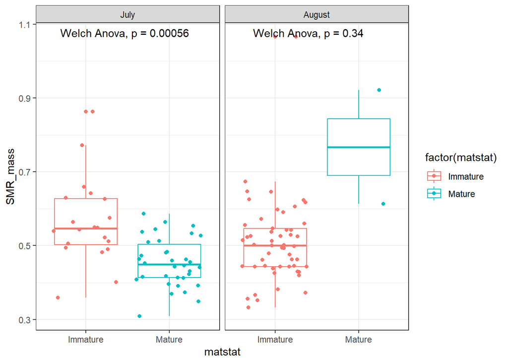

```r
data_matstat <- data %>%
 mutate(matstat = case_when(
    Ratio >= 74 ~ "Mature",
    Ratio < 74 ~ "Immature",
    is.na(Ratio) ~ NA,
    .default = "cusp")
  )

data_matstat_18 <- data_matstat[which(data_matstat$Temp == "18a" & !is.na(data_matstat$matstat)),]

data_matstat_18_July <- data_matstat_18[which(data_matstat_18$Month == "July"),]

#visualize this as two boxplots, with a welch's t-test (due to unequal groups: 36 mature and 73 immature). separate by month to show chronological differences:
ggplot(aes(y = SMR_mass, x = matstat, colour = factor(matstat)), data = data_matstat_18) +
  geom_boxplot() +
  geom_jitter() +
  facet_grid(.~Month) +
  stat_welch_anova_test() +
  theme_bw()
```

```r
# to run a proper pairwise test here, I need to also filter for only individuals which were mature in one month and immature in the other

data_matstat_18_diff <- data_matstat_18[which(data_matstat_18$ID != "B1_78"),] %>%
  group_by(ID) %>%
  mutate(changed = case_when(
    length(unique(matstat))==1 ~ "same",
    length(unique(matstat))==2 ~ "diff",
    .default = "same")
  )%>%
  ungroup() %>%
  filter(changed != "same") %>%
  mutate(
    changed = NULL
  )

data_matstat_18_smr <- data_matstat_18_diff %>%
  dplyr::select(ID, SMR_mass, matstat) %>%
  pivot_wider(
    names_from = matstat,
    values_from = c(SMR_mass)
    )

t_maturity_smr <- t.test(Pair(Mature, Immature) ~ 1, data = data_matstat_18_smr)
t_maturity_smr #shows that individuals have a significantly lower SMR_mass when mature than when immature/regressing
```

```
##
##  Paired t-test
##
## data:  Pair(Mature, Immature)
## t = -2.7051, df = 31, p-value = 0.01099
## alternative hypothesis: true mean difference is not equal to 0
## 95 percent confidence interval:
##  -0.12330061 -0.01729731
## sample estimates:
## mean difference
##     -0.07029896
```

```r
data_matstat_18_mmr <- data_matstat_18_diff %>%
  dplyr::select(ID, MMR_mass, matstat) %>%
  pivot_wider(
    names_from = matstat,
    values_from = c(MMR_mass)
    )

t_maturity_mmr <- t.test(Pair(Mature, Immature) ~ 1, data = data_matstat_18_mmr)
t_maturity_mmr #shows that individuals have a significantly lower MMR_mass when mature than when immature/regressing
```

```
##
##  Paired t-test
##
## data:  Pair(Mature, Immature)
## t = -4.363, df = 31, p-value = 0.000132
## alternative hypothesis: true mean difference is not equal to 0
## 95 percent confidence interval:
##  -0.3268271 -0.1186059
## sample estimates:
## mean difference
##      -0.2227165
```

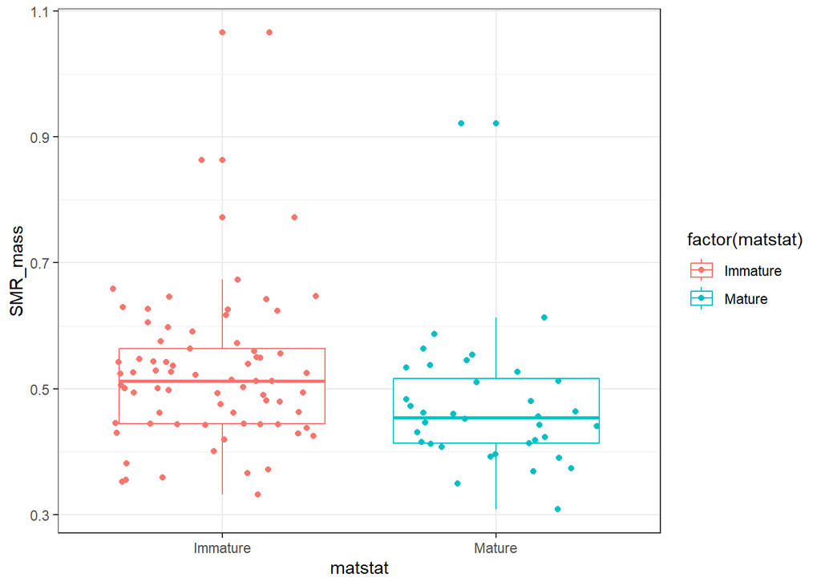

```r
#grouped across month (but note that individuals are repeated twice):
ggplot(aes(y = SMR_mass, x = matstat, colour = factor(matstat)), data = data_matstat_18) +
  geom_boxplot() +
  geom_jitter(aes(group = Month)) +
  theme_bw()
```

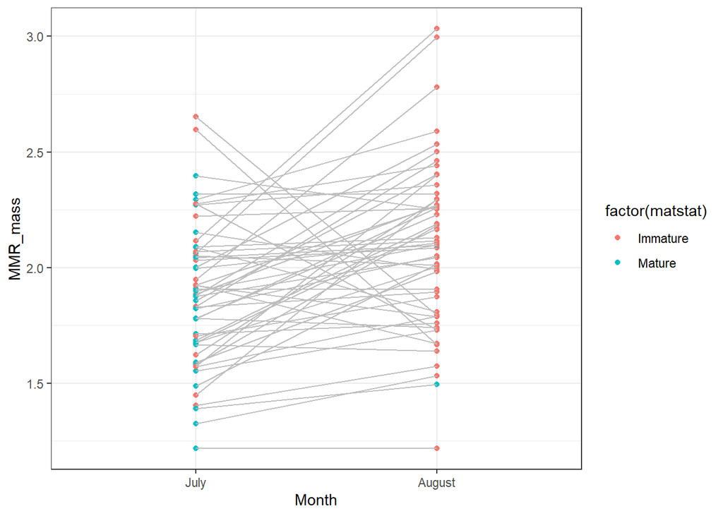

```r
fig5_inset <- ggplot(aes(y = SMR_mass, x = matstat), data = data_matstat_18) +
  geom_boxplot(color = "skyblue") +
  geom_jitter(color = "skyblue") +
  #facet_grid(.~Month) +
  #stat_welch_anova_test() +
  labs(x = " ", y = expression(SMR~(mg~O[2]~h^-1~3.47~g^-1))) +
  theme_classic()

#addressing reviewer comment that changes in MMR between individuals might be of interest
ggplot(aes(y = MMR_mass, x = Month, colour = factor(matstat)), data = data_matstat_18) +
  geom_point() +
  geom_line(aes(group = ID), color = "grey") +
  theme_bw()
```

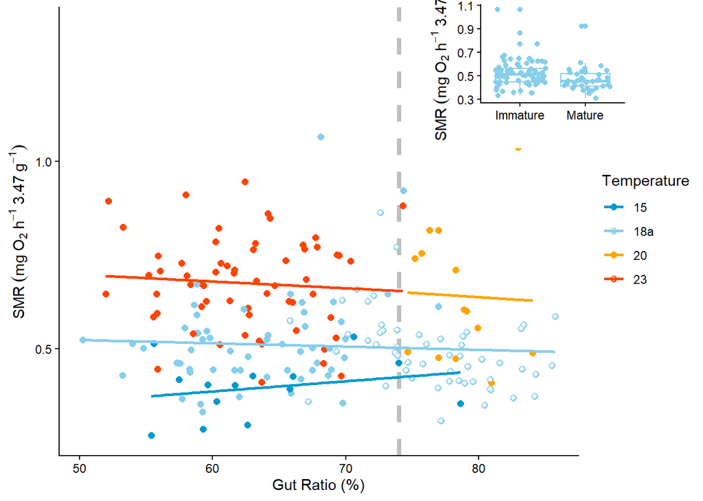

```r
fig6_inset <- ggplot(aes(y = MMR_mass, x = matstat), data = data_matstat_18) +
  geom_boxplot(color = "skyblue") +
  geom_jitter(color = "skyblue") +
  #facet_grid(.~Month) +
  #stat_welch_anova_test() +
  labs(x = " ", y = expression(MMR~(mg~O[2]~h^-1~3.47~g^-1))) +
  theme_classic()

fig5_withinset <-
  ggdraw() +
  draw_plot(fig5) +
  draw_plot(fig5_inset, x = 0.6, y = .705, width = 0.3, height = 0.3)

fig5_withinset
```

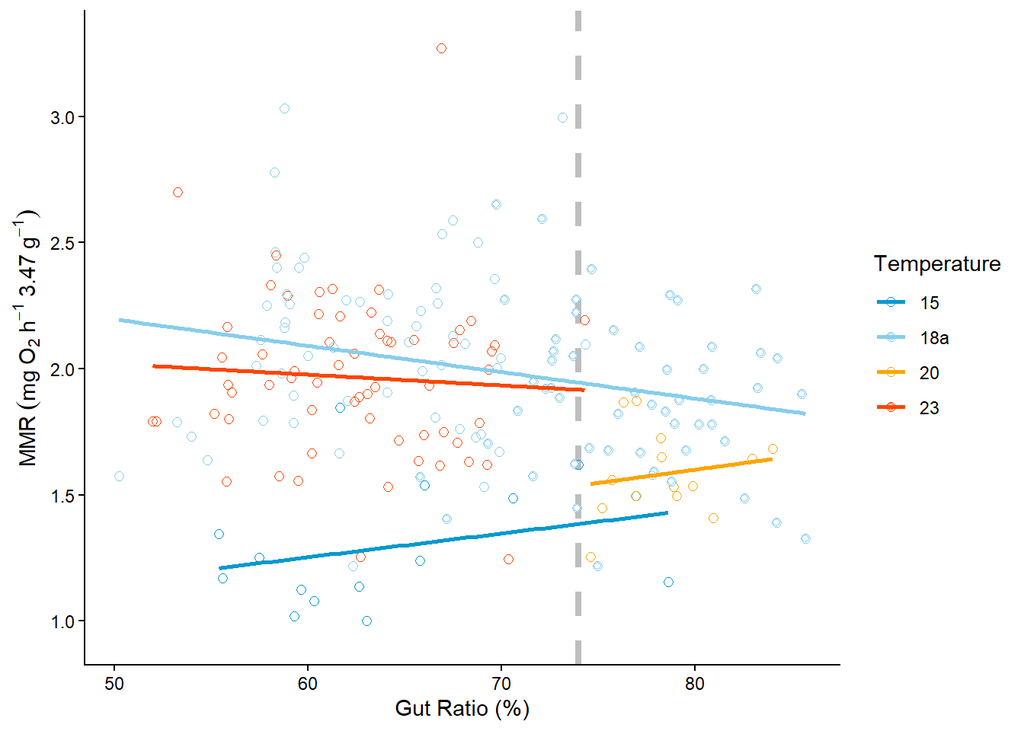

```r
fig6_withinset <-
  ggdraw() +
  draw_plot(fig6) +
  draw_plot(fig6_inset, x = 0.6, y = .7, width = 0.3, height = 0.3)

fig6
```

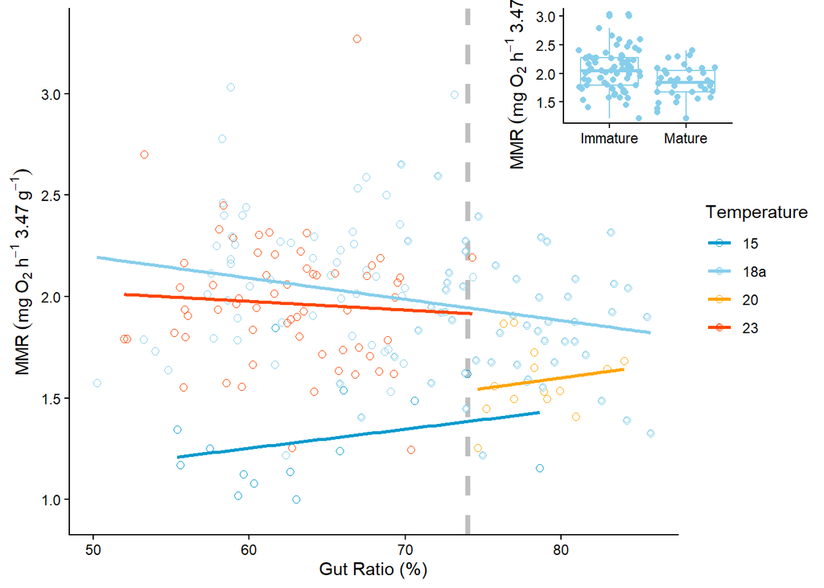

```r
fig6_withinset
```

We could then run a linear regression test between metabolism and gut ratio at 18:

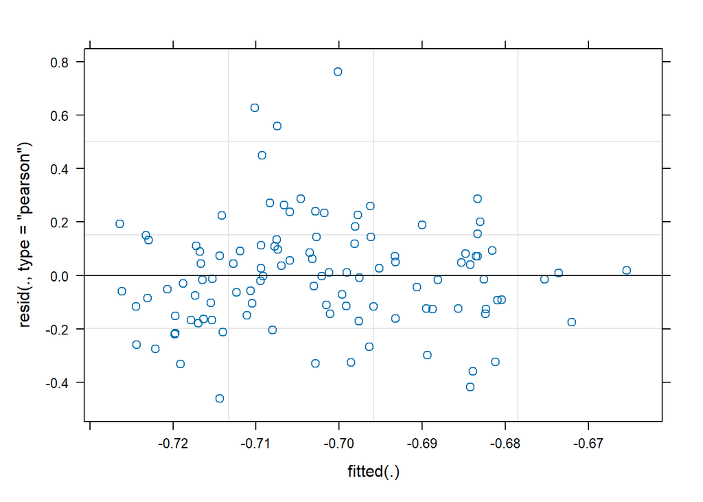

```r
data_matstat_18 <- data_matstat[which(data_matstat$Temp == "18a" & !is.na(data_matstat$matstat)),]

lmod_SMR <- lmer(log(SMR_mass) ~ log(Ratio) + (1 | ID), data = data_matstat_18)
plot(lmod_SMR)
```

```r
summary(lmod_SMR)
```

```
## Linear mixed model fit by REML. t-tests use Satterthwaite's method [
## lmerModLmerTest]
## Formula: log(SMR_mass) ~ log(Ratio) + (1 | ID)
##    Data: data_matstat_18
##
## REML criterion at convergence: -31.1
##
## Scaled residuals:
##     Min      1Q  Median      3Q     Max
## -2.2606 -0.6143 -0.0439  0.5290  3.7382
##
## Random effects:
##  Groups   Name        Variance Std.Dev.
##  ID       (Intercept) 0.00000  0.0000
##  Residual             0.04172  0.2043
## Number of obs: 109, groups:  ID, 55
##
## Fixed effects:
##             Estimate Std. Error       df t value Pr(>|t|)
## (Intercept)  -0.2179     0.6734 107.0000  -0.324    0.747
## log(Ratio)   -0.1142     0.1588 107.0000  -0.719    0.473
##
## Correlation of Fixed Effects:
##            (Intr)
## log(Ratio) -1.000
## optimizer (nloptwrap) convergence code: 0 (OK)
## boundary (singular) fit: see help('isSingular')
```

```r
anova(lmod_SMR)
```

```
## Type III Analysis of Variance Table with Satterthwaite's method
##              Sum Sq  Mean Sq NumDF DenDF F value Pr(>F)
## log(Ratio) 0.021597 0.021597     1   107  0.5177 0.4734
```

```r
emm_SMR <- emtrends(lmod_SMR, ~1, var = "log(Ratio)")
emm_SMR
```

```
##  1       log(Ratio).trend    SE   df lower.CL upper.CL
##  overall           -0.114 0.161 97.4   -0.435    0.206
##
## Degrees-of-freedom method: kenward-roger
## Confidence level used: 0.95
```

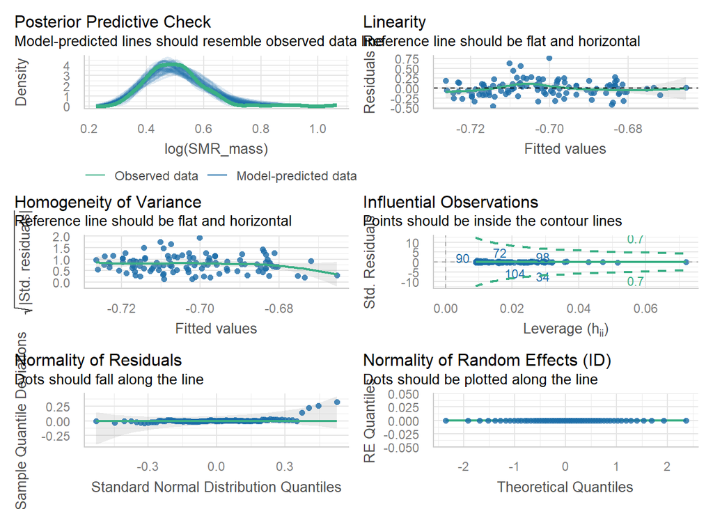

```r
performance::check_model(lmod_SMR, ask = F)
```

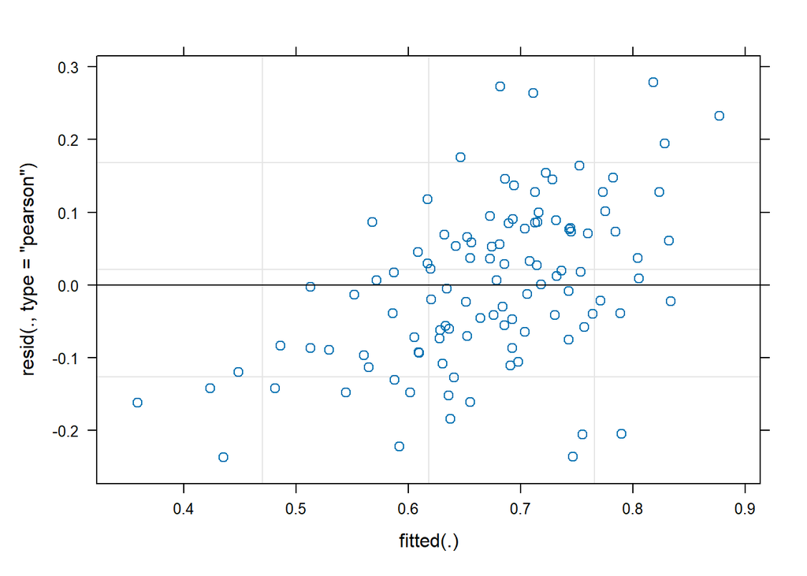

```r
lmod_MMR <- lmer(log(MMR_mass) ~ log(Ratio) + (1 | ID), data = data_matstat_18)
plot(lmod_MMR)
```

```r
summary(lmod_MMR)
```

```
## Linear mixed model fit by REML. t-tests use Satterthwaite's method [
## lmerModLmerTest]
## Formula: log(MMR_mass) ~ log(Ratio) + (1 | ID)
##    Data: data_matstat_18
##
## REML criterion at convergence: -76.4
##
## Scaled residuals:
##      Min       1Q   Median       3Q      Max
## -1.78636 -0.56569  0.00262  0.57678  2.10157
##
## Random effects:
##  Groups   Name        Variance Std.Dev.
##  ID       (Intercept) 0.01242  0.1115
##  Residual             0.01761  0.1327
## Number of obs: 109, groups:  ID, 55
##
## Fixed effects:
##             Estimate Std. Error      df t value Pr(>|t|)
## (Intercept)   2.4303     0.4898 75.9605   4.962 4.16e-06 ***
## log(Ratio)   -0.4148     0.1155 75.8185  -3.592  0.00058 ***
## ---
## Signif. codes:  0 '***' 0.001 '**' 0.01 '*' 0.05 '.' 0.1 ' ' 1
##
## Correlation of Fixed Effects:
##            (Intr)
## log(Ratio) -0.999
```

```r
anova(lmod_MMR)
```

```
## Type III Analysis of Variance Table with Satterthwaite's method
##             Sum Sq Mean Sq NumDF  DenDF F value    Pr(>F)
## log(Ratio) 0.22728 0.22728     1 75.819  12.903 0.0005802 ***
## ---
## Signif. codes:  0 '***' 0.001 '**' 0.01 '*' 0.05 '.' 0.1 ' ' 1
```

```r
emm_MMR <- emtrends(lmod_MMR, ~1, var = "log(Ratio)")
emm_MMR
```

```
##  1       log(Ratio).trend    SE   df lower.CL upper.CL
##  overall           -0.415 0.117 75.8   -0.647   -0.182
##
## Degrees-of-freedom method: kenward-roger
## Confidence level used: 0.95
```

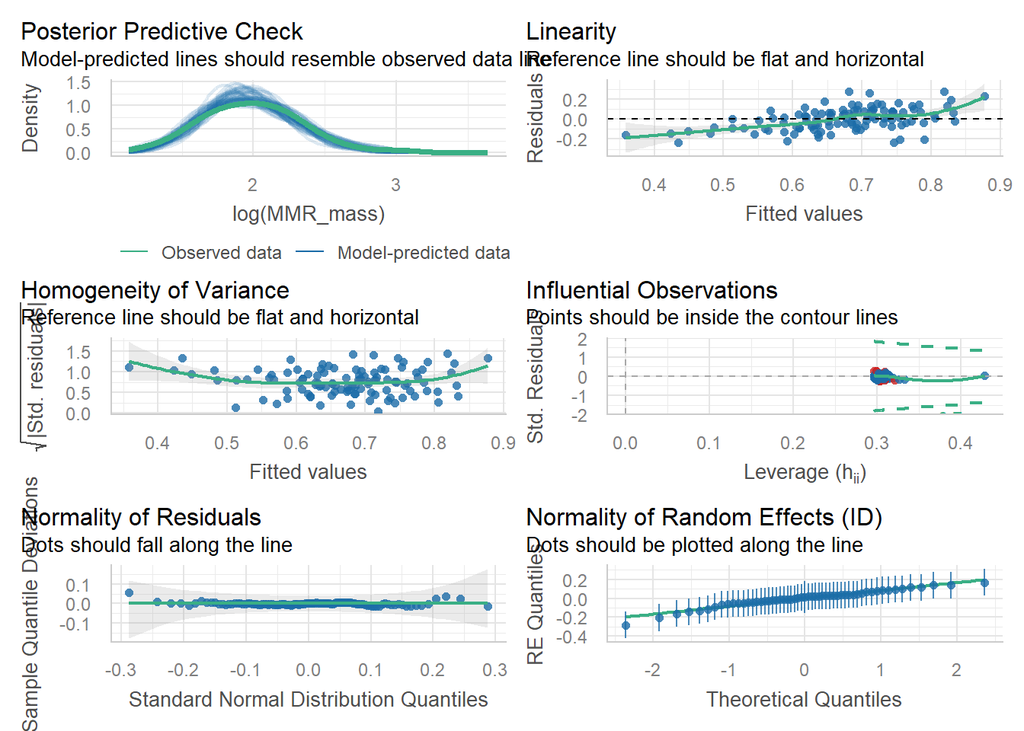

```r
performance::check_model(lmod_MMR, ask = F)
```

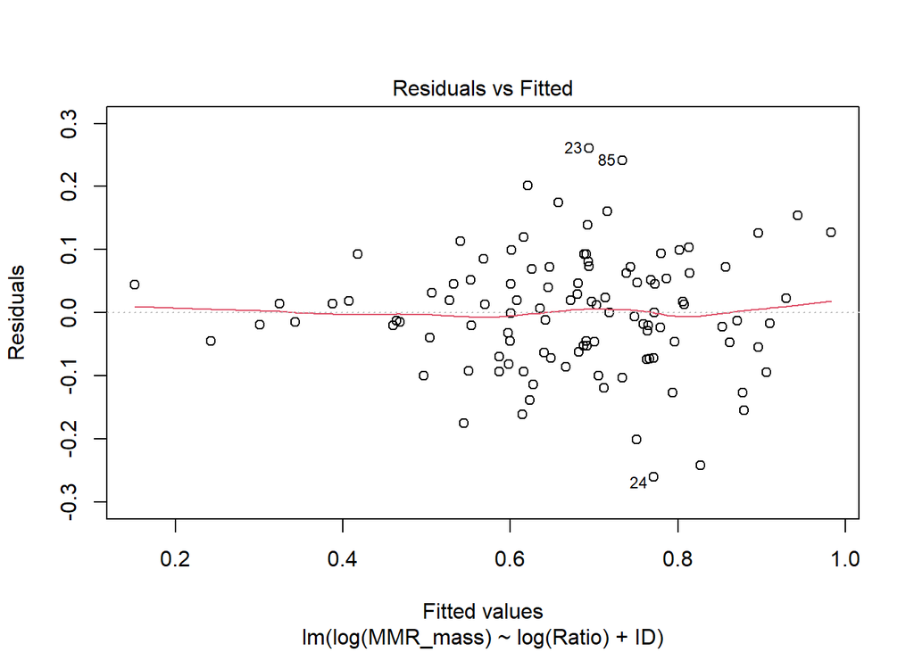

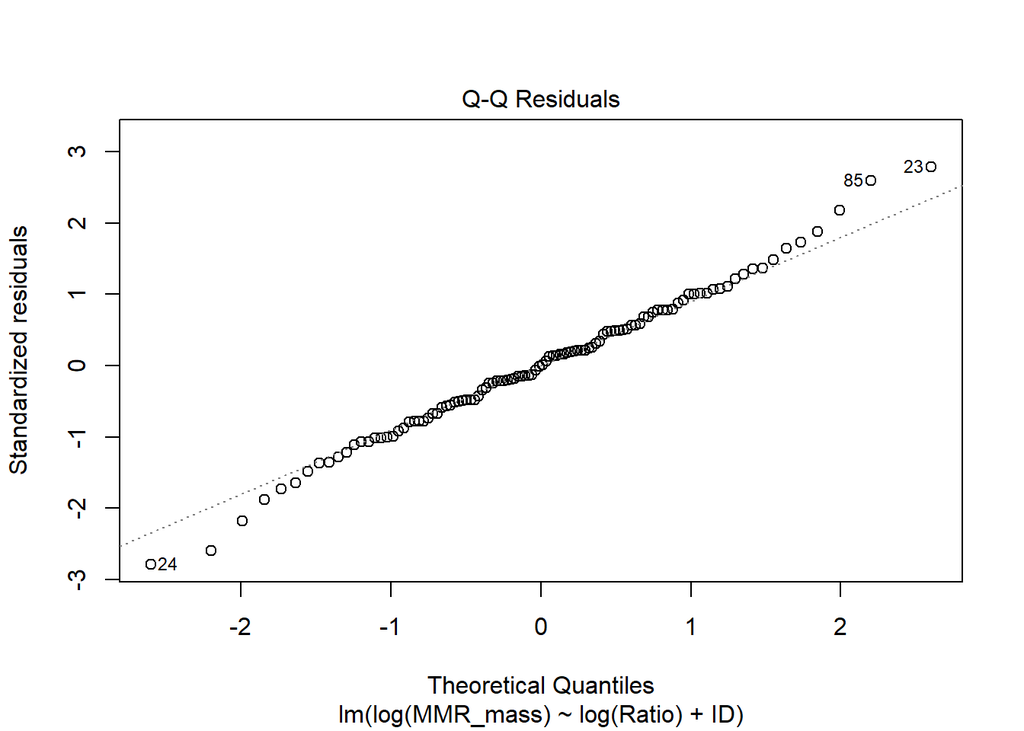

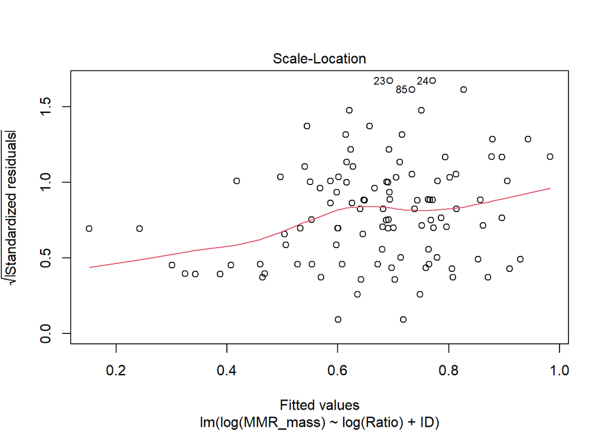

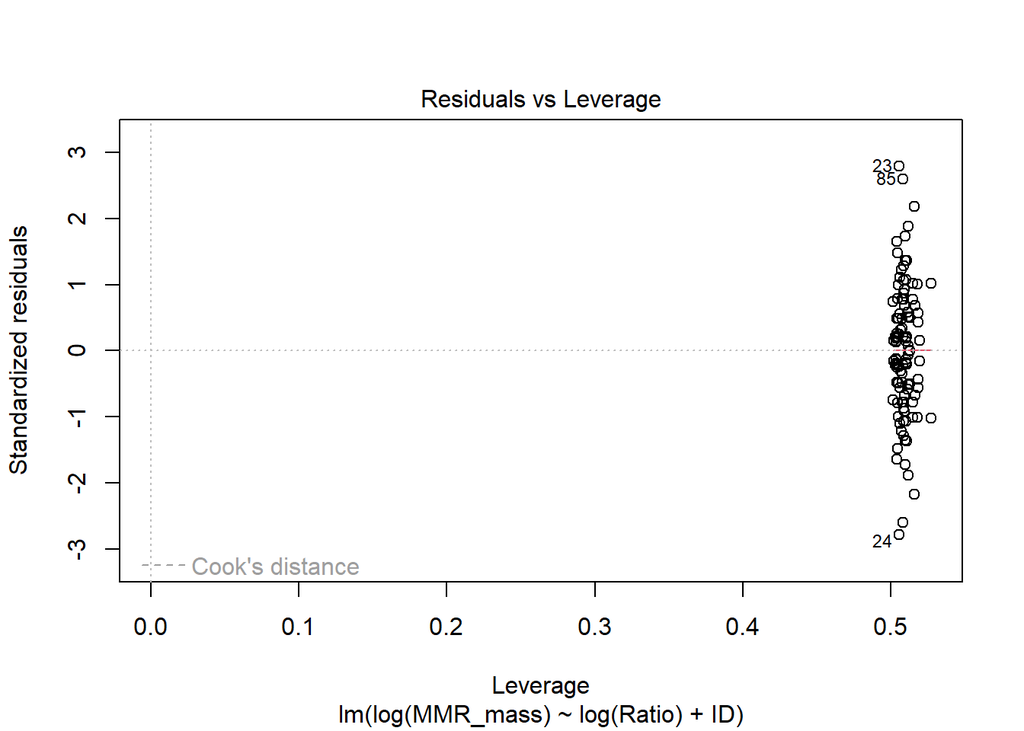

```r
#try again without random effects term (simple linear model) to verify trend is the same, because we saw a positive linear relationship in the residuals vs. predicted vals plot:

#MMR vs. gut ratio as a simple linear model and with ID as a fixed effect
lmod_MMR1 <- lm(log(MMR_mass) ~ log(Ratio) + ID, data = data_matstat_18)
plot(lmod_MMR1)
```

```r
summary(lmod_MMR1)
```

```
##
## Call:
## lm(formula = log(MMR_mass) ~ log(Ratio) + ID, data = data_matstat_18)
##
## Residuals:
##      Min       1Q   Median       3Q      Max
## -0.26059 -0.05422  0.00000  0.05422  0.26059
##
## Coefficients:
##             Estimate Std. Error t value Pr(>|t|)
## (Intercept)  2.40530    0.52831   4.553 3.13e-05 ***
## log(Ratio)  -0.49447    0.12799  -3.863 0.000307 ***
## IDB1_10      0.34273    0.13500   2.539 0.014101 *
## IDB1_11      0.45669    0.13568   3.366 0.001425 **
## IDB1_12      0.38280    0.13614   2.812 0.006891 **
## IDB1_13      0.27376    0.13649   2.006 0.050010 .
## IDB1_14      0.27748    0.13652   2.033 0.047126 *
## IDB1_15      0.28727    0.13628   2.108 0.039782 *
## IDB1_16      0.09647    0.13760   0.701 0.486306
## IDB1_17     -0.11901    0.13443  -0.885 0.379997
## IDB1_18      0.25237    0.13421   1.880 0.065545 .
## IDB1_2       0.34220    0.13466   2.541 0.014007 *
## IDB1_21      0.40361    0.13397   3.013 0.003964 **
## IDB1_22      0.40304    0.13413   3.005 0.004052 **
## IDB1_23      0.50717    0.13375   3.792 0.000385 ***
## IDB1_24      0.31923    0.13583   2.350 0.022519 *
## IDB1_25      0.26689    0.13380   1.995 0.051235 .
## IDB1_29      0.30422    0.13438   2.264 0.027705 *
## IDB1_31      0.66041    0.13811   4.782 1.42e-05 ***
## IDB1_34      0.41490    0.13615   3.047 0.003596 **
## IDB1_38      0.39352    0.13399   2.937 0.004895 **
## IDB1_39      0.40649    0.13344   3.046 0.003607 **
## IDB1_4       0.39787    0.13655   2.914 0.005218 **
## IDB1_41      0.56344    0.13646   4.129 0.000130 ***
## IDB1_42      0.36751    0.13359   2.751 0.008110 **
## IDB1_43      0.29768    0.13423   2.218 0.030885 *
## IDB1_44      0.21384    0.13620   1.570 0.122372
## IDB1_45      0.40318    0.13586   2.968 0.004497 **
## IDB1_46      0.32133    0.13352   2.407 0.019619 *
## IDB1_47      0.59181    0.13368   4.427 4.80e-05 ***
```

[output cut: 17 more lines]

```
## IDB1_73      0.27917    0.13368   2.088 0.041588 *
## IDB1_74      0.12932    0.13283   0.974 0.334689
## IDB1_75      0.47332    0.13382   3.537 0.000851 ***
## IDB1_76      0.42936    0.13434   3.196 0.002349 **
## IDB1_77      0.31767    0.13302   2.388 0.020524 *
## IDB1_78      0.38122    0.16267   2.344 0.022882 *
## IDB1_8       0.16133    0.13359   1.208 0.232552
## IDB1_80      0.52744    0.13392   3.938 0.000241 ***
## IDB1_9       0.13032    0.13922   0.936 0.353492
## ---
## Signif. codes:  0 '***' 0.001 '**' 0.01 '*' 0.05 '.' 0.1 ' ' 1
##
## Residual standard error: 0.1328 on 53 degrees of freedom
## Multiple R-squared:  0.7248, Adjusted R-squared:  0.4392
## F-statistic: 2.538 on 55 and 53 DF,  p-value: 0.0004242
```

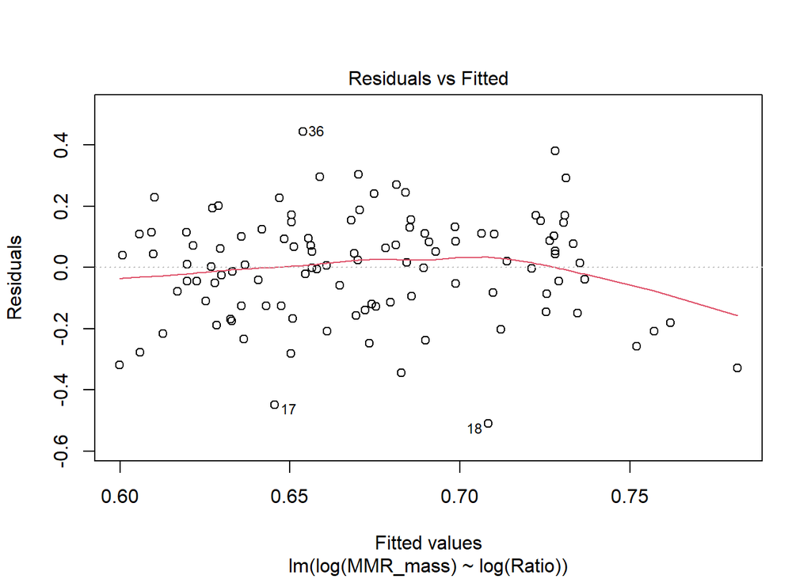

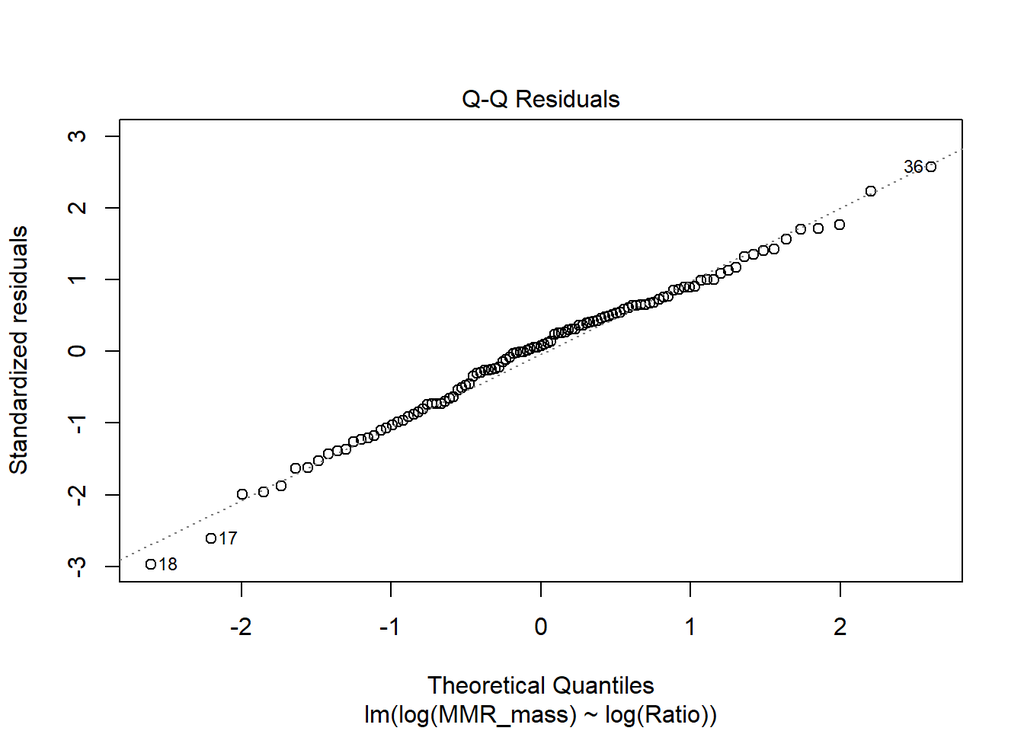

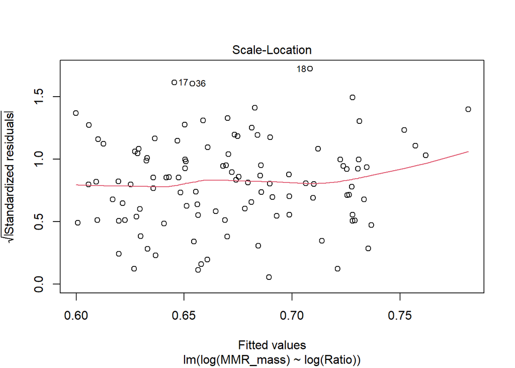

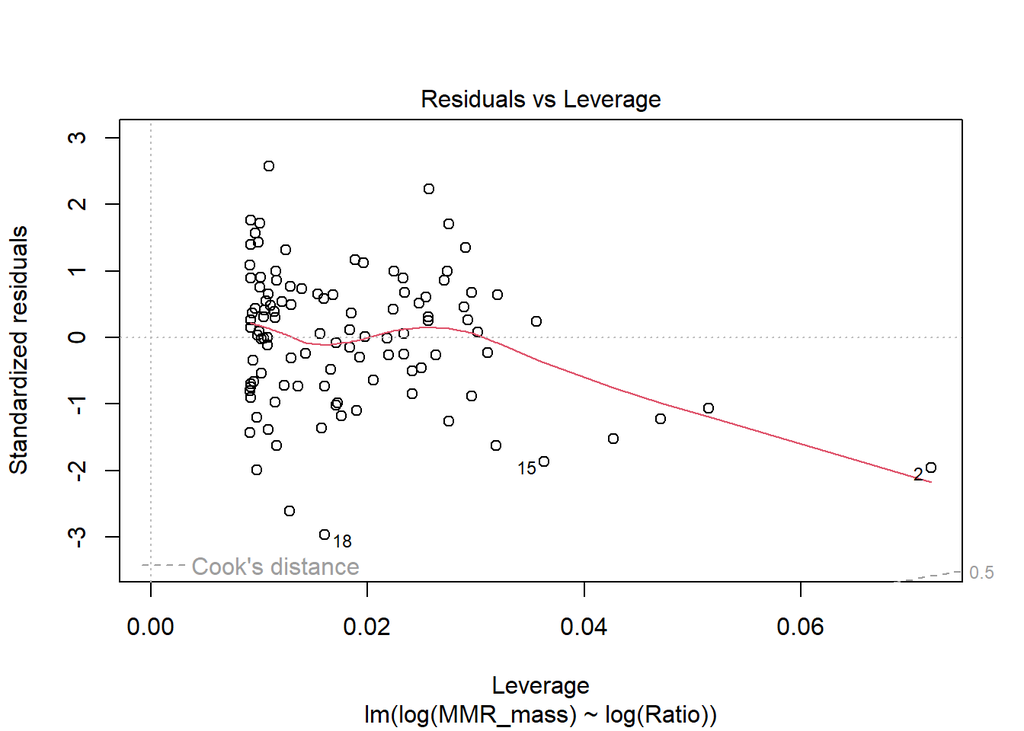

```r
lmod_MMR2 <- lm(log(MMR_mass) ~ log(Ratio), data = data_matstat_18)
plot(lmod_MMR2)
```

```r
summary(lmod_MMR2)
```

```
##
## Call:
## lm(formula = log(MMR_mass) ~ log(Ratio), data = data_matstat_18)
##
## Residuals:
##      Min       1Q   Median       3Q      Max
## -0.51037 -0.12502  0.01403  0.11157  0.44357
##
## Coefficients:
##             Estimate Std. Error t value Pr(>|t|)
## (Intercept)   2.1145     0.5706   3.706 0.000336 ***
## log(Ratio)   -0.3403     0.1345  -2.529 0.012892 *
## ---
## Signif. codes:  0 '***' 0.001 '**' 0.01 '*' 0.05 '.' 0.1 ' ' 1
##
## Residual standard error: 0.1731 on 107 degrees of freedom
## Multiple R-squared:  0.05641,    Adjusted R-squared:  0.04759
## F-statistic: 6.397 on 1 and 107 DF,  p-value: 0.01289
```